# Deep Q Learning with Flappy Bird

Sung Jin Hwang

3/4/2019

# Training a deep neural network to play a game

My project was training a convolutional neural network to play a simple flash based game called “Flappy Bird”. The purpose of this project was to familiarize myself with using Google’s Tensoflow package, and the concept of reinforcement learning. I followed the open git project by Yen Chen Lin at https://github.com/yenchenlin/DeepLearningFlappyBird. This tutorial will explain the concept of the learning process design, and usage of Tensorflow function in developing a network. In order to run the program, type `python gametest.py` inside the directory on terminal.

# Convolutional Neural Network

Convolutional neural network, or CNN, is a type of deep neural network that is commonly applied to analyzing visual imagery. CNNs requires less pre-processing than other image classification algorithms. The network learns the features of the image that are usually hand-egineered for traditional algorithms. This characteristics of CNN in feature design is a major advantage.

A CNN consists of an input layer, multiple hidden layers, and an output layer. The hidden layers of a CNN may be convolutional layers, activation functions (Common function is Rectified Linear Unit (RELU) function), max pooling layers, fully connected layers and normalization layers.

More detailed tutorials on convolutional neural network can be found in: https://towardsdatascience.com/a-comprehensive-guide-to-convolutional-neural-networks-the-eli5-way-3bd2b1164a53

# Reinforcement Learning

This project uses one class of reniforcement learning. Reinforcement learning is a learning design that’s similar to Pavlov’s Dog experiment, where dog was given rewards based on their action in repetitive manner. Reinforcement learning will generate a state where network makes a decision based on that state. The set of rules will decide whether the network received a positive reward or negative reward as a feedback. Based on the reward, the network will adjust it’s values to make better decisions for the next state.

# DeepQLearning

Combining the reinforcement learning to CNN, comes the deep Q learning. In Q-learning, we define Q as a function $Q(s,a)$ which represents the maximum discounted future reward when the network performs action $a$ in the state $s$.

$$Q(s_t,a_t) = max R_{t+1}$$
In the context of this project, we can think of Q as best possible score from performing one action in certain game state. Now we just have to choose the action that yields the highest Q value for each state. Defining the Q function, we can use the Bellman Equation.
$$Q(s,a) = r + \gamma*max_{a'}Q(s',a')$$
Here, $s'$ is the one step future state and $a'$ is the one step future action. Logically, this function means maximum future reward for this state and action is the immediate reward plus maximum future reward for the next state.

We use CNN to implement this Q function.

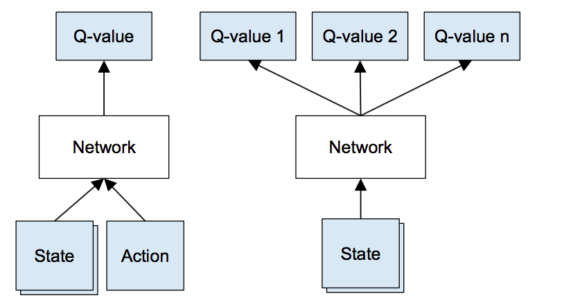

Left: Naive formulation of deep Q-network. Right: More optimized architecture of deep Q-network, used in DeepMind paper.Image Source: https://www.intel.ai/demystifying-deep-reinforcement-learning/#gs.ZVqWFqk6